# An Introduction to ‘SSNbler’: Assembling Spatial Stream Network (`SSN`) Objects in R

Erin E Peterson, Michael Dumelle, Alan R Pearse, Dan Teleki, and Jay M Ver Hoef

# 1 Background

Data collected in streams frequently exhibit unique patterns of spatial autocorrelation resulting from the branching network structure, longitudinal (i.e., upstream/downstream) connectivity, directional water flow, and differences in flow volume upstream of junctions (i.e., confluences) in the network (Peterson et al., 2013). In addition, stream networks are embedded within geographic (i.e., 2-D) space, with the terrestrial landscape often having a strong influence on observations collected on the stream network. Ver Hoef & Peterson (2010) describe how to fit spatial statistical models on stream networks (i.e., spatial stream-network models) that capture the unique and complex spatial dependencies inherent in streams. These stream network models can be fit using the ‘SSN2’ **R** package (Dumelle, Peterson, Ver Hoef, Pearse, & Isaak, 2024). To use ‘SSN2’, however, users must provide the spatial, topological, and attribute data in a specific format called an `SSN` object. The ‘SSNbler’ **R** package, which we introduce here, is an adaptation of the STARS ArcGIS toolset (Peterson & Ver Hoef, 2014) for the **R** programming language. ‘SSNbler’ generates formats, assembles, and validates `SSN` objects that can be used for statistical modeling in ‘SSN2’.

In this vignette, we use ‘SSNbler’ to create the `SSN` object `MiddleFork04.ssn` used by ‘SSN2’. First, we load ‘SSNbler’ into our current **R** session.

```r
library(SSNbler)
```

A few input datasets are included in the ‘SSNbler’ package:

- `MF_streams`: An `sf` object with `LINESTRING` geometry representing a portion of the Middle Fork stream network in Idaho, USA.
- `MF_obs`: An `sf` object with `POINT` geometry containing observed summer mean stream temperature observations at 45 unique locations on `MF_streams`.
- `MF_pred1km`: An `sf` object with `POINT` geometry containing unsampled locations spaced at one-kilometer intervals throughout `MF_streams`. This prediction dataset represents 175 locations where predictions of some response variable (i.e., temperature) may be desired.
- `MF_CapeHorn`: An `sf` object with `POINT` geometry containing 654 unsampled locations spaced at 10-meter intervals throughout Cape Horn Creek in `MF_streams`.

To provide context, the observed data in `MF_obs` will be used to build statistical models and make predictions at the locations in `MF_pred1km` and `MF_CapeHorn` using the **R** package ‘SSN2’. Documentation for each dataset can be found by running `help()`. For example, to learn more about `MF_streams`, run `help("MF_streams", package = "SSNbler")`.

While these datasets come with ‘SSNbler’ and can be loaded via `data()`, we focus here on a more realistic workflow for the user. We start with a collection of spatial datasets installed alongside ‘SSNbler’ in the `streamsdata` folder that represent the Middle Fork stream network. In `streamsdata` are GeoPackages (more on this later) representing the stream network, observed data, and prediction data (optional) required to create an SSN object. To prevent ‘SSNbler’ functions from reading and writing to this folder, we copy it to R’s temporary directory and store the path to this folder:

```r
copy_streams_to_temp()
path <- paste0(tempdir(), "/streamsdata")
```

Then we can read in the relevant data using `st_read` from the ‘sf’ **R** package (Pebesma, 2018), which comes installed alongside ‘SSNbler’. Note that the input data can be in any vector data format that can be imported into R and stored as an `sf` object with `LINESTRING` or `POINT` geometry (e.g., shapefile, GeoJSON, GeoPackage, SpatiaLite, PostGIS).

```r
library(sf)
MF_streams <- st_read(paste0(path, "/MF_streams.gpkg"))
MF_obs <- st_read(paste0(path, "/MF_obs.gpkg"))
MF_pred1km <- st_read(paste0(path, "/MF_pred1km.gpkg"))
MF_CapeHorn <- st_read(paste0(path, "/MF_CapeHorn.gpkg"))
```

Notice that the line (`MF_Streams`) and point features (`MF_obs`, `MF_pred1km`, and `MF_CapeHorn`) have `LINESTRING` and `POINT` geometry types, which are required in ‘SSNbler’. If these datasets had `MULTILINESTRING` or `MULTIPOINT` geometry types, the ‘sf’ function `st_cast` could be used to convert to the required geometry types. All of the input data have an Albers Equal Area Conic projection (EPSG 102003) and distances are measured in meters. It is important that all input datasets have the same map projection, which must be a projected coordinate system and not a geographic coordinate system measured in Latitude and Longitude. The ‘sf’ function `st_transform` can be used to reproject `sf` objects in **R**.

We previously mentioned these data are stored in `streamsdata` in a GeoPackage format. GeoPackages, like shapefiles, are a way to store spatial data. We prefer GeoPackages over shapefiles because they offer better support for high precision numeric data compared to the traditional DBF (dBASE) format (used in shapefiles), which limits the precision to 10 decimal places when *writing* (not reading) to local files from **R**. This is problematic because several important columns ‘SSNbler’ adds and ‘SSN2’ uses contain very small values ranging from zero to one. If these columns are truncated it can lead to difficult-to-diagnose errors when models are fit in ‘SSN2’. GeoPackages do not have this limitation. To learn more about GeoPackages, [visit here](https://www.geopackage.org/).

Before working with any of the input files, we visualize the stream network, observed sites, and prediction sites using the **R** package ‘ggplot2’ (Wickham, 2016).

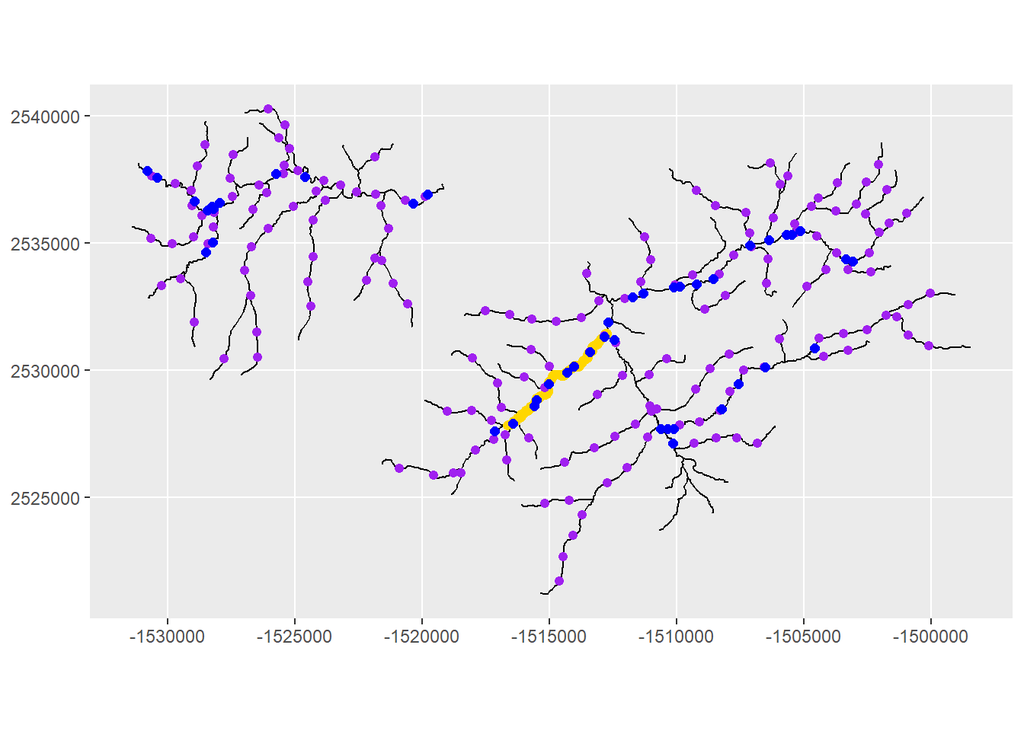

```r
library(ggplot2)
ggplot() +
  geom_sf(data = MF_streams) +
  geom_sf(data = MF_CapeHorn, color = "gold", size = 1.7) +
  geom_sf(data = MF_pred1km, colour = "purple", size = 1.7) +
  geom_sf(data = MF_obs, color = "blue", size = 2) +
  coord_sf(datum = st_crs(MF_streams))
```

In the figure above, there are two subnetworks from `MF_Streams` (black lines). Point features from `MF_obs` (blue dots) and `MF_pred1km` (purple dots) are found on both networks, while `MF_CapeHorn` point features (yellow dots) are only found on one of the two networks.

# 2 The Landscape Network

‘SSNbler’ makes use of a data structure called a Landscape Network (LSN), which is a type of graph used to represent spatial context and relationships with additional geographic information (Theobald et al., 2006). In a LSN, streams are represented as a collection of directed edges, where the directionality is determined by the digitized direction of the line features. Nodes are located at the end points of edges (i.e., end nodes) and represent topologic breaks in the edges. For a more detailed description of the LSN, see Peterson & Ver Hoef (2014).

There are four topologically valid node categories in a LSN:

- **Source**: Water flow originates at these nodes and flows downstream. An edge that begins at a source node is called a headwater segment. Source nodes do not receive flow from any upstream edges.
- **Outlet**: Flow terminates at these nodes. This node is the most downstream point in an edge network. We refer to an edge that terminates at an outlet as an outlet segment. Note that a streams dataset may contain multiple subnetworks with associated outlets.
- **Confluence**: Multiple edges converge, or flow into, a single node.
- **Pseudonode**: One edge flows in and one edge flows out of a single node. While these nodes are not topologically problematic, an excessive number of pseudonodes can slow down geoprocessing operations for large datasets.

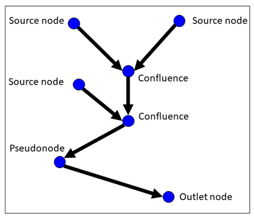

A landscape network (LSN). Nodes are denoted by blue circles, with the node category labelled. Edges are denoted by black arrows, with the arrow indicating flow direction (i.e., digitized direction).

Each edge is associated with two nodes, which correspond to the upstream and downstream end nodes of the edge. When more than one edge flows into or out of the node, they *share* a node. Thus, there should always be a single node at the intersection of edges. If there is more or less than one node at an intersection, it is a topological error. If these errors are not corrected, the connectivity between line features and the observed and prediction sites associated with them will not be accurately represented in the `SSN` object or the spatial statistical models subsequently fit to the data. In this vignette, we assume that `MF_streams` has already been checked and topologically corrected. Two tutorials have been created with detailed instructions about identifying and correcting topological errors in the LSN, as well as other topological restrictions that are not permitted (please see ‘Correcting topological errors using SSNbler and QGIS’ or ‘Correcting topological errors using SSNbler and ArcGIS Pro’). These tutorials are available for download within the relevant folders on GitHub at [this link](https://github.com/pet221/SSNbler/tree/main/inst/tutorials).

## 2.1 Building the Landscape Network

The LSN is created using the `lines_to_lsn()` function, which generally requires these arguments:

- `streams`: An `sf` object with `LINESTRING` geometry that represents the stream network.
- `lsn_path`: A path to the directory in which the LSN output files will be stored. This directory will be created if it does not exist.
- `check_topology`: Logical indicating whether to check for topological errors in `streams`.
- `snap_tolerance`: Two nodes separated by a Euclidean distance $\le$ `snap_tolerance` will be assumed connected. Distance is measured in map units (i.e., projection units for `streams`).
- `topo_tolerance`: Two nodes separated by a Euclidean distance $\le$ `topo_tolerance` are flagged as potential topological errors in the network.

We create a LSN associated with `MF_streams` by running

```r
## Set path for new folder for lsn
lsn.path <- paste0(tempdir(), "/mf04")

edges <- lines_to_lsn(
  streams = MF_streams,
  lsn_path = lsn.path,
  check_topology = TRUE,
  snap_tolerance = 0.05,
  topo_tolerance = 20,
  overwrite = TRUE
)
```

The `lines_to_lsn()` function writes a minimum of five files to `lsn_path`:

- `nodes.gpkg`: A GeoPackage with `POINT` geometry features representing LSN nodes. It contains a unique node identifier column, `pointid`, and another column named `nodecat`, which contains the node type (pseudonode, confluence, source, outlet).
- `edges.gpkg`: A GeoPackage with `LINESTRING` geometry features representing LSN edges, which contains all of the columns in `streams` and a unique edge (i.e., reach) identifier column named `rid`.
- `nodexy.csv`: A comma-separated value (csv) file with the `pointid` and x and y coordinates for each node.
- `noderelationships.csv`: A csv file with three columns used to describe the directional relationship between nodes and edges. The column `rid` is the edge identifier, while the `fromnode` and `tonode` contain the `pointid` value for the upstream and downstream node, respectively.
- `relationships.csv`: A csv file that describes the directional relationship between edges using two columns named `fromedge` and `toedge`, which contain the edge `rid` values.

Together these five files describe the geographic and topological relationships between edges in the network, while preserving flow direction.

When `check_topology = TRUE`, `lines_to_lsn()` also checks the topology of the network. When potential topological errors are identified, they are saved at the location specified by `lsn_path` as a GeoPackage named `node_errors.gpkg` with `POINT` geometry.

It is important to pay attention to the output messages from `lines_to_lsn()` that are printed to the **R** console. In this example, the message is `No obvious topological errors detected and node_errors.gpkg was NOT created.` This suggests that the LSN edges are error-free, but it is still a good idea in practice to visually assess maps of the node `nodecat` values to look for obvious errors, as described in the topology editing tutorials mentioned previously. If `node_errors.gpkg` was created, then potential topological errors were identified, which must be checked and corrected before moving on to the next spatial processing steps.

## 2.2 Incorporating Sites Into the Landscape Network

After creating the error-free LSN using `lines_to_lsn()`, observed and prediction datasets are incorporated into the LSN using `sites_to_lsn()`. The function snaps (i.e., moves) point locations to the closest edge location and generates new information describing the topological relationships between edges and sites in the LSN. `sites_to_lsn()` generally requires these arguments:

- `sites`: An `sf` object with `POINT` geometry that contains the observed or prediction locations.
- `edges`: An `sf` object containing the edges in the LSN generated using `lines_to_lsn()`.
- `snap_tolerance`: A numeric distance in map units. If the distance to the nearest edge feature is less than or equal to `snap_tolerance`, sites are snapped to the relevant edge. If the distance to the nearest edge feature is greater than `snap_tolerance`, the point feature is not snapped to an edge or included in the output.
- `save_local`: If `TRUE` (the default), the snapped sites are written to `lsn_path` with name specified by `file_name`.
- `lsn_path`: A path to the directory where the LSN created via `lines_to_lsn()` is stored.
- `file_name`: Output file name for the snapped sites, which are saved in `lsn_path` in GeoPackage format.

We run `sites_to_lsn` for the `MF_obs` (observed) data:

```r
obs <- sites_to_lsn(
  sites = MF_obs,
  edges = edges,
  lsn_path = lsn.path,
  file_name = "obs",
  snap_tolerance = 100,
  save_local = TRUE,
  overwrite = TRUE
)
```

In the code above, `sites_to_lsn()` writes a GeoPackage named `obs.gpkg` to `lsn_path` and also returns these snapped sites as an `sf` object named `obs`. The new dataset contains the original columns in `sites` and three new columns:

- `rid`: The edge `rid` value where the snapped site resides.
- `ratio`: Describes the site location on the edge. It is calculated by dividing the length of the edge found between the downstream end node and the site location by the total edge length.
- `snapdist`: The Euclidean distance in map units the site was moved.

The `rid` value provides information about where a site is in relation to all of the other edges and sites in an LSN, while the `ratio` value can be used to identify where *exactly* a site is on the edge. Note that the `sites_to_lsn` function must be run for each dataset, even if the site locations already intersect edge features.

It is important to pay attention to the message output in the **R** console because it indicates how many of the sites were successfully snapped to the LSN. In this case, the message says `Snapped 45 out of 45 sites to LSN`. If some sites were not snapped, the `snap_tolerance` value should be increased until all sites are snapped. The `snapdist` column can then be used to identify sites that were moved relatively large distances to ensure they were snapped to the correct edge.

Prediction datasets (optional) represent spatial locations where predictions from a spatial stream-network model may be desired. They are optional, but must also be incorporated into the LSN using `sites_to_lsn()` before predictions can be made using a fitted model. We add the `MF_pred1km` and `MF_capehorn` prediction datasets to the LSN by running

```r
preds <- sites_to_lsn(
  sites = MF_pred1km,
  edges = edges,
  save_local = TRUE,
  lsn_path = lsn.path,
  file_name = "pred1km.gpkg",
  snap_tolerance = 100,
  overwrite = TRUE
)

capehorn <- sites_to_lsn(
  sites = MF_CapeHorn,
  edges = edges,
  save_local = TRUE,
  lsn_path = lsn.path,
  file_name = "CapeHorn.gpkg",
  snap_tolerance = 100,
  overwrite = TRUE
)
```

Note that a LSN can contain an unlimited number of prediction datasets, but only one set of observations. The `sites_to_lsn` function must be run separately for every observed and prediction dataset. While this may at first seem tedious, it provides the user the opportunity to examine each output dataset individually, ensuring that all sites are snapped to the LSN and the correct edge feature.

The `lines_to_lsn` and `sites_to_lsn` functions are used to produce a topologically corrected LSN containing edges, observed sites, and prediction sites (optional). This LSN provides the foundation for all of the remaining spatial data processing steps and the spatial statistical models. Creating the LSN is often the most time-consuming step in the spatial statistical modeling workflow, especially if the edges or sites contain a large number of features or the stream network has many topological errors. However, it is critical that the spatial and topological relationships are accurately represented in the LSN and the subsequent spatial statistical models.

The LSN created using `lines_to_lsn()` and `sites_to_lsn()` is stored in memory and also in a local folder defined using `lsn_path`. The LSN contains at least six components. The edges, nodes, and observed sites contain the spatial features and attribute data *within* each dataset, while the three tables (nodexy, noderelationships, and relationships) describe the relationships *between* edges and sites. These tables are not stored in memory but are accessed by subsequent ‘SSNbler’ functions. Prediction datasets may also be included in the LSN if desired. By default, all ‘SSNbler’ functions will update the files stored locally in `lsn_path` *and* return an updated `sf` object. However, the `save_local` argument can be set to FALSE in most functions if the user would prefer not to save results locally.

LSN components are stored in memory as `sf` objects and also in a local LSN directory as GeoPackages and comma separated value (csv) files, which are accessed using other SSNbler functions.

| **LSN Component** | **In Memory** | **Local LSN Directory** |
| --- | --- | --- |
| edges | sf object, `LINESTRING` geometry | GeoPackage |
| observed sites | sf object, `POINT` geometry | GeoPackage |
| prediction sites (optional) | sf object, `POINT` geometry | GeoPackage |
| nodes |  | GeoPackage |
| nodexy table |  | csv file |
| noderelationships table |  | csv file |
| relationships table |  | csv file |

Once the LSN has been created, the next steps are to calculate the information needed to fit spatial stream-network models.

# 3 Calculating Upstream Distance

The “upstream distance” represents the hydrologic distance (i.e., distance between locations when movement is restricted to the stream network) between the network outlet and each feature. For an edge, the distance is measured to the upstream end node of the line feature. The upstream distance for the $j$th edge, $upDist_j$, is:

$$upDist_j = \sum_{k \in D_j}{L_k},$$

where $L_j$ is the length of each edge and $D_j$ is the set of edges found in the path between the network outlet and the $j$th edge, including the $j$th edge.

The upstream distance for each edge is calculated using the `updist_edges()` function, which generally requires these arguments:

- `edges`: An `sf` object containing the edges in the LSN generated using `lines_to_lsn()`.
- `save_local`: A logical indicating whether the updated edges should be saved to `lsn_path` in GeoPackage format. Default is TRUE.
- `lsn_path`: `LSN` pathname where `edges` and `relationships.csv` are stored locally.
- `calc_length`: A logical indicating whether a column representing line length should be calculated and added to `edges`. It is important to set `calc_length = TRUE` if the edge features have been edited.

```r
edges <- updist_edges(
  edges = edges,
  save_local = TRUE,
  lsn_path = lsn.path,
  calc_length = TRUE
)

names(edges) ## View edges column names
```

```
#>  [1] "rid"        "COMID"      "GNIS_NAME"  "REACHCODE"  "FTYPE"
#>  [6] "FCODE"      "AREAWTMAP"  "SLOPE"      "rcaAreaKm2" "h2oAreaKm2"
#> [11] "Length"     "upDist"     "geom"
```

Two columns are added to edges and saved in `edges.gpkg`. `Length` represents the length of each edge in map units and `upDist` is the upstream distance for each edge.

For sites, the upstream distance is calculated a little differently because it is the hydrologic distance between the network outlet and each *site*. The upstream distance for site $i$, $upDist_i$, is calculated as:
$$upDist_i = r_i L_i + \sum_{k \in D^*_j}{L_k},$$

where $r_i$ is the `ratio` value for $site_i$, $L_i$ is the length of the edge $site_i$ resides on, and $D^*_j$ is the set of edges found in the path between the network outlet and $site_i$, excluding the edge $site_i$ resides on.

Upstream distance is calculated for each site using the `updist_sites()` function, which generally requires a few arguments:

- `sites`: A named list of one or more `sf` objects with `POINT` geometry, which have been incorporated into the LSN using `sites_to_lsn()`.
- `edges:` An `sf` object representing edges that have been processed using `lines_to_ssn()` and `updist_edges()`.
- `length_col`: The name of the column in `edges` that represents edge length.
- `save_local`: A logical indicating whether the updated sites should be saved to `lsn_path` in GeoPackage format. Default is TRUE.
- `lsn_path`: The LSN pathname where the `sites` and `edges` GeoPackages reside. Must be specified if `save_local` is TRUE.

```r
site.list <- updist_sites(
  sites = list(
    obs = obs,
    pred1km = preds,
    CapeHorn = capehorn
  ),
  edges = edges,
  length_col = "Length",
  save_local = TRUE,
  lsn_path = lsn.path
)

names(site.list) ## View output site.list names
```

```
#> [1] "obs"      "pred1km"  "CapeHorn"
```

```r
names(site.list$obs) ## View column names in obs
```

```
#>  [1] "rid"        "STREAMNAME" "COMID"      "AREAWTMAP"  "SLOPE"
#>  [6] "ELEV_DEM"   "Source"     "Summer_mn"  "MaxOver20"  "C16"
#> [11] "C20"        "C24"        "FlowCMS"    "AirMEANc"   "AirMWMTc"
#> [16] "rcaAreaKm2" "h2oAreaKm2" "ratio"      "snapdist"   "geom"
#> [21] "upDist"
```

The data stored in `upDist` are later used to calculate the directional hydrologic distances between observed and prediction locations in the ‘SSN2’ package. If we plot the edges and observations, assigning color based on the `upDist` column, it is apparent that the upstream distance increases from the outlet to headwater streams, as expected.

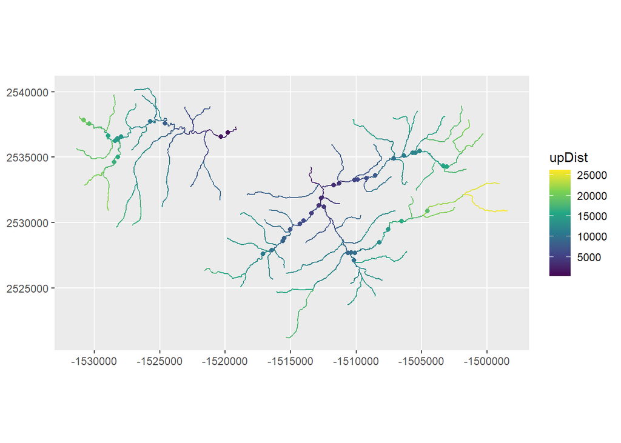

```r
ggplot() +
  geom_sf(data = edges, aes(color = upDist)) +
  geom_sf(data = site.list$obs, aes(color = upDist)) +
  coord_sf(datum = st_crs(MF_streams)) +
  scale_color_viridis_c()
```

# 4 Calculating Additive Function Values (AFVs)

Spatial weights are used to split the tail-up covariance function upstream of network confluences, which allows for the disproportionate influence of one upstream edge over another (e.g., a large stream channel converges with a smaller one) on downstream values. Calculating the spatial weights is a three-step process: 1) calculating the segment proportional influence (PI), 2) calculating the additive function values (AFVs), and 3) calculating the spatial weights. Steps 1) and 2) are undertaken in ‘SSNbler’, while Step 3) is calculated in the package ‘SSN2’ when spatial stream-network models are fit.

The segment PI for each edge, $\omega_j$, is defined as the relative influence of the $j$th edge feature on the edge directly downstream. In the following example, $\omega_j$ is based on cumulative watershed area for the downstream node of each edge, $A_j$, which is used as a surrogate for flow volume. However, simpler measures could be used, such as Shreve’s stream order (Shreve 1966) or equal weighting, as long as a value exists for every line feature in edges (i.e., missing data are not allowed). It is also preferable to use a column that does not contain values equal to zero, which we explain in more detail below.

When two edges, denoted $j$ and $k$, converge at a node, the segment PI for the $j$th edge is:

$$\omega_j=\frac{A_j}{A_j + A_k}.$$

Notice that the segment PI values are ratios. Therefore, the sum of the PI values for edges directly upstream of a single node always sum to one. Also note that $\omega_j=0$ when $A_j=0$.

The AFVs for the $j$th edge, $AFV_j$, is equal to the product of the segment PIs found in the path between the edge and the network outlet, including edge $j$ itself.

$$AFV_j = \prod_{k \in D_j}{\omega_k}.$$

If $\omega_j=0$, the AFV values for edges upstream of the $j$th edge will also be equal to zero. This may not be problematic if the $j$th edge is a headwater segment without an observed site. However, it can have a significant impact on the covariance structure of the tail-up model when the $j$th edge is found lower in the stream network.

AFVs are calculated for every edge in the network using `afv_edges()`, which generally requires these arguments:

- `edges`: An `sf` object representing edges that has been processed using `lines_to_lsn()`.
- `lsn_path`: The LSN pathname where the `edges` reside.
- `infl_col`: The name of the numeric column in edges used to calculate the segment PI for each edge feature. Missing values are not allowed.
- `segpi_col`: The name of the new column in edges where segment PI values are stored.
- `afv_col`: The name of the new column in edges where AFVs are stored.
- `save_local`: A logical indicating whether the updated edges should be saved to `lsn_path` in GeoPackage format. Default is TRUE.

Note that we use a variable representing cumulative watershed area that is already present in `edges` (`h2oAreaKm2`) to create the segment PI values:

```r
summary(edges$h2oAreaKm2) ## Summarize and check for zeros
```

```
#>     Min.  1st Qu.   Median     Mean  3rd Qu.     Max.
#>   0.0036   2.4534   5.9877  22.6237  28.2600 209.8989
```

```r
edges <- afv_edges(
  edges = edges,
  infl_col = "h2oAreaKm2",
  segpi_col = "areaPI",
  afv_col = "afvArea",
  lsn_path = lsn.path
)

names(edges) ## Look at edges column names
```

```
#>  [1] "rid"        "COMID"      "GNIS_NAME"  "REACHCODE"  "FTYPE"
#>  [6] "FCODE"      "AREAWTMAP"  "SLOPE"      "rcaAreaKm2" "h2oAreaKm2"
#> [11] "Length"     "upDist"     "areaPI"     "afvArea"    "geom"
```

```r
summary(edges$afvArea) ## Summarize the AFV column
```

```
#>     Min.  1st Qu.   Median     Mean  3rd Qu.     Max.
#> 0.004709 0.026168 0.066095 0.160335 0.169575 1.000000
```

The AFVs are a product of ratios, which means that the AFVs are always between zero and one ($0 \le AFV \le 1$). The AFV for the most downstream edge in a network will always be one. If AFVs do not meet this requirement, then an error has occurred.

Once the AFVs have been added to edges, they can be calculated for the observations and (if relevant) prediction sites. The AFV for any site is equivalent to the AFV of the edge it resides on. If there are multiple sites on a single edge feature, their AFVs will be equal. Also note that when the AFV for the $i$th site is zero, the covariance between data collected at the $i$th site and every other site will also be zero. For more on additive function values, see Ver Hoef & Peterson (2010) and Peterson & Ver Hoef (2010).

The `afv_sites` function is used to create an AFV column in a list of observed and prediction sites. The inputs include:

- `sites`: A named list of one or more `sf` objects with `POINT` geometry, which have been incorporated into the LSN using `sites_to_lsn()`.
- `edges`: An `sf` object representing edges, which contains `afv_col` created using `edges_afv()`.
- `afv_col`: The name of the column containing the AFVs in `edges`. A new column with this name will be added to `sites`.
- `save_local`: If `TRUE` (the default), the updated sites are written to `lsn_path`.
- `lsn_path`: A path to the directory where the LSN created via `lines_to_lsn()` is stored. Required when `save_local = TRUE`.

```r
site.list <- afv_sites(
  sites = site.list,
  edges = edges,
  afv_col = "afvArea",
  save_local = TRUE,
  lsn_path = lsn.path
)

names(site.list$pred1km) ## View column names in pred1km
```

```
#>  [1] "rid"        "COMID"      "AREAWTMAP"  "SLOPE"      "ELEV_DEM"
#>  [6] "FlowCMS"    "AirMEANc"   "AirMWMTc"   "rcaAreaKm2" "h2oAreaKm2"
#> [11] "ratio"      "snapdist"   "upDist"     "afvArea"    "geom"
```

```r
summary(site.list$pred1km$afvArea) ## Summarize AFVs in pred1km and look for zeros
```

```
#>     Min.  1st Qu.   Median     Mean  3rd Qu.     Max.
#> 0.009894 0.031219 0.047469 0.104969 0.112882 1.000000
```

Each `sf` dataset in `sites.list` now has an AFV column, `afvArea`, which was generated based on cumulative watershed area. All AFVs should meet the requirement that they are between zero and one.

# 5 Assembling the SSN Object

The last data processing step is to assemble the `SSN` object using the `ssn_assemble` function.

The key arguments in `ssn_assemble()` include:

- `edges`: An `sf` object representing edges that has been processed using `lines_to_lsn()`, `updist_edges()`, and `afv_edges()`.
- `lsn_path`: The LSN pathname where the `edges` and all observation and prediction site datasets reside.
- `obs_sites:` Optional. A single `sf` object representing observed sites, which has been processed using `sites_to_lsn()`, `updist_sites()`, and `afv_sites()`. Default is is NULL.
- `preds_list`: Optional. A named list of one or more `sf` objects representing prediction site datasets that have been processed using `sites_to_lsn()`, `updist_sites()`, and `afv_sites()`. Default is NULL.
- `ssn_path`: The path to a local directory where the output files will be saved. A `.ssn` extension will be added if it is not included.
- `import`: Logical indicating whether the output files should be imported and returned as an `SSN` object.
- `check`: Logical indicating whether the validity of the `SSN` object should be checked using `ssn_check()`. Default is TRUE.
- `afv_col`: Character vector containing the names of the AFV columns that will be checked when `check = TRUE`. Columns must be present in `edges`, `obs_sites`, and `preds_list`, if they are included.

```r
mf04_ssn <- ssn_assemble(
  edges = edges,
  lsn_path = lsn.path,
  obs_sites = site.list$obs,
  preds_list = site.list[c("pred1km", "CapeHorn")],
  ssn_path = paste0(path, "/MiddleFork04.ssn"),
  import = TRUE,
  check = TRUE,
  afv_col = "afvArea",
  overwrite = TRUE
)
```

```
#>
#>
#> SSN object is valid: TRUE
```

```r
class(mf04_ssn) ## Get class
```

```
#> [1] "SSN"
```

```r
names(mf04_ssn) ## print names of SSN object
```

```
#> [1] "edges" "obs"   "preds" "path"
```

```r
names(mf04_ssn$preds) ## print names of prediction datasets
```

```
#> [1] "pred1km"  "CapeHorn"
```

The outputs of `ssn_assemble()` are stored locally in a directory with a `.ssn` extension and in memory as an object of class `SSN` when `import = TRUE`. At a minimum, the new `.ssn` directory will contain:

1. `edges.gpkg`: edges in GeoPackage format
2. `sites.gpkg`: observed sites in GeoPackage format (if included)
3. `Prediction datasets`: (e.g., `CapeHorn.gpkg` and `pred1km.gpkg`) in GeoPackage format (if included)
4. `netIDx.dat files`: one text file for each unique subnetwork in edges containing information describing the topological relationships between edges.

When `import = TRUE`, the spatial data stored in the `.ssn` directory are imported into **R** and stored in memory as an `SSN` object. The `netIDx.dat` files are combined behind the scenes into an SQLite database named `binaryID.db`, which is saved in the `.ssn` directory. Most users will not need to access the `binaryID.db` or the `netIDx.dat` files, but a more detailed description about how the topological relationships are stored can be found in Peterson & Ver Hoef (2014).

The `SSN` object itself is a list containing four elements:

1. `edges`: An `sf` object representing edges.
2. `obs`: An `sf` object of observed sites.
3. `preds`: Named list of `sf` objects representing prediction site datasets.
4. `path`: Character string describing the path to the `.ssn` where the `SSN` components are stored locally.

Including observed sites is optional in `ssn_assemble` and when they are missing `obs` will contain `NA` rather than an `sf` object. Most users will likely include observations because they are needed to fit spatial statistical stream-network models. Nevertheless, this option provides the flexibility to include additional functionality in future ‘SSNbler’ versions. More specifically to create an `SSN` object based on existing stream network data, generate artificial observed locations at various locations throughout the network, and simulate data at those locations using the ‘SSN2’ function `ssn_simulate`.

The `path` element provides a critical link between the `.ssn` directory and the `SSN` object stored in R. This is important because the ‘SSN2’ package reads and writes data to this directory during the spatial stream-network modeling workflow.

The `ssn_assemble` function also adds several important columns to the edges, obs, and prediction datasets.

- `edges`:
  - `netID`: A unique network identifier
- `obs` and `preds`:
  - `netID` The network identifier value for the edge the site resides on
  - `pid`: A unique identifier for each measurement (i.e., point feature).
  - `locID`: A unique identifier for each location. Note that repeated measurements at a site will have the same `locID` value, but different `pid` values.

A `netgeom` (short for network geometry) column is also added to each of the sf objects stored within an `SSN` object. The `netgeom` column contains a character string describing the position of each line (`edges`) and point (`obs` and `preds`) feature in relation to one another. The format of the `netgeom` column differs depending on whether it is describing a feature with `LINESTRING` or `POINT` geometry. For `edges`, the format of `netgeom` is

$$\texttt{ENETWORK (netID rid upDist)},$$
and for sites
$$\texttt{SNETWORK (netID rid upDist ratio pid locID)}.$$

The information stored in these columns is used to keep track of the spatial and topological relationships in the network. The data used to define `netgeom` is stored in the edges, observed sites, and prediction sites datasets. We store an additional copy of this critical information as text in the `netgeom` column because it reduces the chances that users will unknowingly make changes to these data, which in turn could change how relationships are represented in spatial stream-network models.

# 6 Plotting an SSN Object

The ‘SSNbler’ and ‘SSN2’ packages do not include generic plotting functions for `SSN` objects because the functionality is already available in the package ‘ggplot2’. As an example, we create a plot of the `SSN` object. The edges are displayed in blue, with the linewidth proportional to cumulative watershed area column, `h2oAreaKm2`. The summer stream temperature observations (`Summer_mn`) are shown using the viridis color palette, with `pred1km` locations shown as smaller white dots:

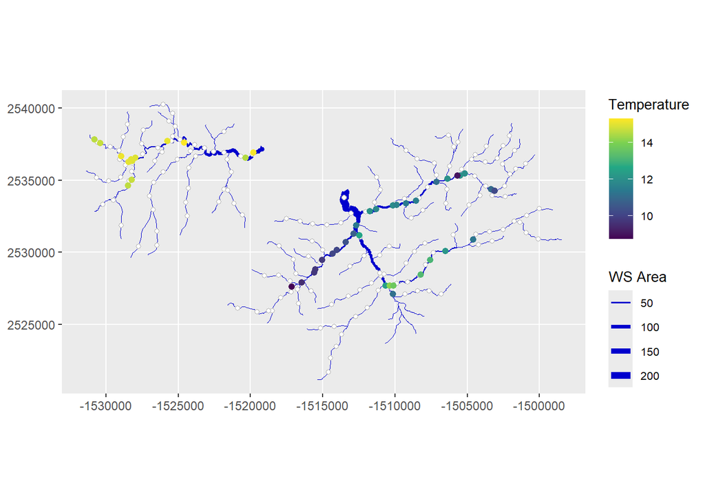

Mean summer stream temperature (Temperature) and cumulative watershed area (WS AREA) for the Middle Fork stream network. Prediction locations are white circles.

```r
ggplot() +
  geom_sf(
    data = mf04_ssn$edges,
    color = "medium blue",
    aes(linewidth = h2oAreaKm2)
  ) +
  scale_linewidth(range = c(0.1, 2.5)) +
  geom_sf(
    data = mf04_ssn$preds$pred1km,
    size = 1.5,
    shape = 21,
    fill = "white",
    color = "dark grey"
  ) +
  geom_sf(
    data = mf04_ssn$obs,
    size = 1.7,
    aes(color = Summer_mn)
  ) +
  coord_sf(datum = st_crs(MF_streams)) +
  scale_color_viridis_c() +
  labs(color = "Temperature", linewidth = "WS Area") +
  theme(
    legend.text = element_text(size = 8),
    legend.title = element_text(size = 10)
  )
```

Notice the different ways the sf objects for the edges, obs, and pred1km datasets are accessed in the `SSN` object and used for plotting in the calls to `geom_sf`. Any valid plotting function for sf objects and ggplot in general can be used to create attractive plots of `SSN` object components.

# 7 Incorporating Data Into an sf or SSN Object

The edges, observations, and prediction locations are stored as `sf` objects, which allows these data to be accessed, manipulated, deleted, or replaced in the same way as other `sf` objects. The `sf` objects found in an `SSN` object can be accessed just like an element in any named list. In this example, the edges and observed sites are accessed using calls to `mf04_ssn$edges` and `mf04_ssn$obs`, respectively. The prediction sites are accessed a bit differently (e.g.,`mf04_ssn$preds$pred1km`) because `preds` is itself a named list.

Users often want to incorporate additional data into the edges, observations, or prediction datasets to generate AFVs, for use as model covariates, or to create more meaningful plots. For example, the US EPA’s StreamCat database (Hill, Weber, Leibowitz, R, & Thornbrugh, 2015) contains hundreds of variables describing stream segment characteristics in the conterminous US. It is relatively easy to join these and other data to the `sf` objects in **R** before or after the `SSN` object is assembled. An online search will show there are numerous functions available for joining an `sf` object to a variety of data formats (e.g.,`data.frames`, `tibbles`, `vectors`, `sp` objects). However, if the result of the join is not an `sf` object, it must be converted to one before running additional functions in ‘SSNbler’ and ‘SSN2’ (see `st_as_sf` in the ‘sf’ package).

# 8 Fitting a Spatial Stream Network Model Using SSN2

We can now use the mf04_ssn object to fit a spatial stream-network model relating mean summer temperature to elevation (`ELEV_DEM`) and mean annual precipitation (`AREAWTMAP`), with the exponential tail-up, spherical tail-down, and Gaussian Euclidean covariance functions. Notice that `additive = "afvArea"`, which is the column we created earlier using the `afv_edges` and `afv_sites` functions.

```r
library(SSN2)

## Generate hydrologic distance matrices
ssn_create_distmat(mf04_ssn)

## Fit the model
ssn_mod <- ssn_lm(
  formula = Summer_mn ~ ELEV_DEM + AREAWTMAP,
  ssn.object = mf04_ssn,
  tailup_type = "exponential",
  taildown_type = "spherical",
  euclid_type = "gaussian",
  additive = "afvArea"
)
summary(ssn_mod)
```

```
#>
#> Call:
#> ssn_lm(formula = Summer_mn ~ ELEV_DEM + AREAWTMAP, ssn.object = mf04_ssn,
#>     tailup_type = "exponential", taildown_type = "spherical",
#>     euclid_type = "gaussian", additive = "afvArea")
#>
#> Residuals:
#>      Min       1Q   Median       3Q      Max
#> -2.73430 -1.43161 -0.04368  0.83251  1.39377
#>
#> Coefficients (fixed):
#>              Estimate Std. Error z value Pr(>|z|)
#> (Intercept) 78.214857  12.189379   6.417 1.39e-10 ***
#> ELEV_DEM    -0.028758   0.005808  -4.952 7.35e-07 ***
#> AREAWTMAP   -0.008067   0.004125  -1.955   0.0505 .
#> ---
#> Signif. codes:  0 '***' 0.001 '**' 0.01 '*' 0.05 '.' 0.1 ' ' 1
#>
#> Pseudo R-squared: 0.4157
#>
#> Coefficients (covariance):
#>               Effect     Parameter   Estimate
#>   tailup exponential  de (parsill)  1.348e+00
#>   tailup exponential         range  8.987e+05
#>   taildown spherical  de (parsill)  2.647e+00
#>   taildown spherical         range  1.960e+05
#>      euclid gaussian  de (parsill)  1.092e-04
#>      euclid gaussian         range  1.805e+05
#>               nugget        nugget  1.660e-02
```

As expected, there is strong evidence ($p < 0.001$) that elevation is negatively related to mean summer temperature, while there is moderate evidence ($p \approx 0.05$) that precipitation is negatively related to mean summer temperature. To learn more about fitting spatial stream-network models using the ‘SSN2’ package, visit the package website at https://usepa.github.io/SSN2/.

# R Code Appendix

```r
library(SSNbler)
copy_streams_to_temp()
path <- paste0(tempdir(), "/streamsdata")
library(sf)
MF_streams <- st_read(paste0(path, "/MF_streams.gpkg"))
MF_obs <- st_read(paste0(path, "/MF_obs.gpkg"))
MF_pred1km <- st_read(paste0(path, "/MF_pred1km.gpkg"))
MF_CapeHorn <- st_read(paste0(path, "/MF_CapeHorn.gpkg"))
library(ggplot2)
ggplot() +
  geom_sf(data = MF_streams) +
  geom_sf(data = MF_CapeHorn, color = "gold", size = 1.7) +
  geom_sf(data = MF_pred1km, colour = "purple", size = 1.7) +
  geom_sf(data = MF_obs, color = "blue", size = 2) +
  coord_sf(datum = st_crs(MF_streams))
knitr::include_graphics("valid_nodes.png")
## Set path for new folder for lsn
lsn.path <- paste0(tempdir(), "/mf04")

edges <- lines_to_lsn(
  streams = MF_streams,
  lsn_path = lsn.path,
  check_topology = TRUE,
  snap_tolerance = 0.05,
  topo_tolerance = 20,
  overwrite = TRUE
)
obs <- sites_to_lsn(
  sites = MF_obs,
  edges = edges,
  lsn_path = lsn.path,
  file_name = "obs",
  snap_tolerance = 100,
  save_local = TRUE,
  overwrite = TRUE
)
preds <- sites_to_lsn(
  sites = MF_pred1km,
  edges = edges,
  save_local = TRUE,
  lsn_path = lsn.path,
  file_name = "pred1km.gpkg",
  snap_tolerance = 100,
  overwrite = TRUE
)

capehorn <- sites_to_lsn(
  sites = MF_CapeHorn,
  edges = edges,
  save_local = TRUE,
  lsn_path = lsn.path,
  file_name = "CapeHorn.gpkg",
  snap_tolerance = 100,
  overwrite = TRUE
)
edges <- updist_edges(
  edges = edges,
  save_local = TRUE,
  lsn_path = lsn.path,
  calc_length = TRUE
)

names(edges) ## View edges column names
site.list <- updist_sites(
  sites = list(
    obs = obs,
    pred1km = preds,
    CapeHorn = capehorn
  ),
  edges = edges,
  length_col = "Length",
  save_local = TRUE,
  lsn_path = lsn.path
)

names(site.list) ## View output site.list names
names(site.list$obs) ## View column names in obs
ggplot() +
  geom_sf(data = edges, aes(color = upDist)) +
  geom_sf(data = site.list$obs, aes(color = upDist)) +
  coord_sf(datum = st_crs(MF_streams)) +
  scale_color_viridis_c()
summary(edges$h2oAreaKm2) ## Summarize and check for zeros

edges <- afv_edges(
  edges = edges,
  infl_col = "h2oAreaKm2",
  segpi_col = "areaPI",
  afv_col = "afvArea",
  lsn_path = lsn.path
)

names(edges) ## Look at edges column names
summary(edges$afvArea) ## Summarize the AFV column
site.list <- afv_sites(
  sites = site.list,
  edges = edges,
  afv_col = "afvArea",
  save_local = TRUE,
  lsn_path = lsn.path
)

names(site.list$pred1km) ## View column names in pred1km
summary(site.list$pred1km$afvArea) ## Summarize AFVs in pred1km and look for zeros
mf04_ssn <- ssn_assemble(
  edges = edges,
  lsn_path = lsn.path,
  obs_sites = site.list$obs,
  preds_list = site.list[c("pred1km", "CapeHorn")],
  ssn_path = paste0(path, "/MiddleFork04.ssn"),
  import = TRUE,
  check = TRUE,
  afv_col = "afvArea",
  overwrite = TRUE
)

class(mf04_ssn) ## Get class
names(mf04_ssn) ## print names of SSN object
names(mf04_ssn$preds) ## print names of prediction datasets
ggplot() +
  geom_sf(
    data = mf04_ssn$edges,
    color = "medium blue",
    aes(linewidth = h2oAreaKm2)
  ) +
  scale_linewidth(range = c(0.1, 2.5)) +
  geom_sf(
    data = mf04_ssn$preds$pred1km,
    size = 1.5,
    shape = 21,
    fill = "white",
    color = "dark grey"
  ) +
  geom_sf(
    data = mf04_ssn$obs,
    size = 1.7,
    aes(color = Summer_mn)
  ) +
  coord_sf(datum = st_crs(MF_streams)) +
  scale_color_viridis_c() +
  labs(color = "Temperature", linewidth = "WS Area") +
  theme(
    legend.text = element_text(size = 8),
    legend.title = element_text(size = 10)
  )
library(SSN2)

## Generate hydrologic distance matrices
ssn_create_distmat(mf04_ssn)

## Fit the model
ssn_mod <- ssn_lm(
  formula = Summer_mn ~ ELEV_DEM + AREAWTMAP,
  ssn.object = mf04_ssn,
  tailup_type = "exponential",
  taildown_type = "spherical",
  euclid_type = "gaussian",
  additive = "afvArea"
)
summary(ssn_mod)
```

# References

Dumelle, M., Peterson, E. E., Ver Hoef, J. M., Pearse, A. R., & Isaak, D. J. (2024). SSN2: The next generation of spatial stream network modeling in R. *Journal of Open Source Software*, *9*(99), 6389. https://doi.org/10.21105/joss.06389

Hill, R. A., Weber, M. H., Leibowitz, S. G., R, O. A., & Thornbrugh, D. J. (2015). The stream-catchment (StreamCat) dataset: A database of watershed metrics for the conterminous united states. *Journal of the American Water Resources Association*, *52*(1), 120–128. https://doi.org/10.1111/1752-1688.12372

Pebesma, E. (2018). Simple Features for R: Standardized Support for Spatial Vector Data. *The R Journal*, *10*(1), 439–446. https://doi.org/10.32614/RJ-2018-009

Peterson, E. E., & Ver Hoef, J. (2014). STARS: An ArcGIS toolset used to calculate the spatial information needed to fit spatial statistical models to stream network data. *Journal of Statistical Software*, *56*, 1–17.

Peterson, E. E., & Ver Hoef, J. M. (2010). A mixed-model moving-average approach to geostatistical modeling in stream networks. *Ecology*, *91*(3), 644–651.

Peterson, E. E., Ver Hoef, J. M., Isaak, D. J., Falke, J. A., Fortin, M.-J., Jordan, C. E., … Wenger, S. J. (2013). Modelling dendritic ecological networks in space: An integrated network perspective. *Ecology Letters*, *16*(5), 707–719.

Theobald, D. M., Norman, J. B., Peterson, E., Ferraz, S., Wade, A., & Sherburne, M. (2006). Functional linkage of water basins and streams (FLoWS) v1 user’s guide: ArcGIS tools for network-based analysis of freshwater ecosystems. *Natural Resource Ecology Lab, Colorado State University, Fort Collins, CO*, *43*.

Ver Hoef, J. M., & Peterson, E. E. (2010). A moving average approach for spatial statistical models of stream networks. *Journal of the American Statistical Association*, *105*(489), 6–18.

Wickham, H. (2016). *ggplot2: Elegant graphics for data analysis*. Springer-Verlag New York. Retrieved from https://ggplot2.tidyverse.org